# Cuba Montastraea cavernosa Microsatellite and SNP Analyses and Figures in R

Alexis Sturm

4/14/2020

# About this document

Code to produce these figures was generated with help from Ryan Eckert, if you think this walkthrough is helpful check out similar ones for Symbiodiniaceae ITS2 analyses here.

# Basic setup of R environment

## Loading required packages

Make sure to set the working directory: setwd(“~/path/to/directory/with/data”)

For the following analyses we will require the use of multiple different R packages, we can use the package *pacman* to quickly load them.

```r
if (!require("pacman")) install.packages("pacman")
pacman::p_load("adegenet", "dendextend", "ggdendro", "hierfstat", "Imap", "patchwork", "poppr", "RColorBrewer", "reshape2", "StAMPP", "tidyverse", "vcfR", "vegan", "paletteer", "WGCNA")
```

# Figures and analyses

## Figure 1: IBS dendrogram with clones

The following chunk of code uses the IBS matrix generated from ANGSD to produce an Identity-By-State Dendrogram which we can use to ensure that technical replicates are clustering together and to identify natural clones from the SNP dataset.

```r
cloneBams = read.table("sample_list")[,1] # list of bam files
cloneMa = as.matrix(read.table("trimmed_mc_w_clones.ibsMat")) # reads in IBS matrix produced by ANGSD
dimnames(cloneMa) = list(cloneBams,cloneBams)
clonesHc = hclust(as.dist(cloneMa),"ave")

cloneMeta = read.table("clonePops.txt", sep="\t") # list of bams files and their populations
clonePops = cloneMeta$V2

cloneDend = as.dendrogram(hclust(as.dist(cloneMa),"ave"))
dendPops = labels2colors(as.numeric(as.factor(as.numeric(clonePops))), colorSeq = brewer.pal(8, "Dark2"))[order.dendrogram(cloneDend)]
```

Then you can export the figure as a .eps file

```r
setEPS()
postscript("clonesDend.eps", width = 17, height = 6, pointsize = 12)

cloneDend %>%
  hang.dendrogram %>% # hang the leaves
  set("leaves_pch", 19) %>% set("leaves_cex", 1.8) %>% set("leaves_col", dendPops) %>%
  set("branches_lwd",1.5) %>% set("labels_cex", 1.3) %>%
  plot(ylab="Genetic Distance (1-IBS)", cex.lab=1.3, xlab=NA, sub=NA, main=NA) %>%
  abline(h = 0.15, col = "red", lty = 3, lwd = 2) %>% axis(side = 2, lwd = 1.5)
```

## Figure 2: Heterozygosity plot

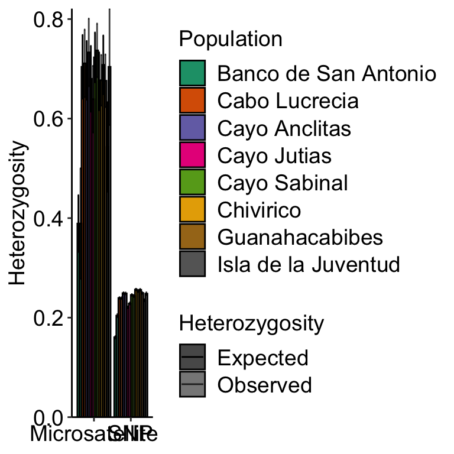

```r
cubaHetero = read.csv("Heterozygosity_Values.csv", header = TRUE)

hetPlotA = ggplot(cubaHetero, aes(x = Analysis.Type, y = Heterozygosity, fill = Population,
                                  alpha = Type)) +
  geom_bar(position = position_dodge(), stat = "identity", color = 'black') +
  scale_y_continuous(expand = c(0, 0)) +
  geom_errorbar(aes(ymin = Heterozygosity-Error, ymax = Heterozygosity+Error),
                width = 0.6, position = position_dodge(0.9)) +
  scale_fill_brewer(palette = "Dark2") +
  scale_alpha_manual(values = c(1, 0.75), name = "Heterozygosity") +
  labs(x ="Analysis Type", y = "Heterozygosity") +
  guides(fill = guide_legend(order = 1)) +
  theme_classic()

hetPlot = hetPlotA + theme(panel.border = element_blank(),
                           panel.grid.major = element_blank(),
                           panel.grid.minor = element_blank(),
                           axis.line = element_line(color = "black"),
                           axis.text = element_text(size = 14, color = "black"),
                           axis.title.y = element_text(size = 14),
                           legend.title = element_text(size = 14),
                           legend.text = element_text(size = 14),
                           axis.title.x = element_blank())

hetPlot
```